# Technologie wytwarzania elementów urządzeń mechatronicznych

dr hab. inż. Marcin Słoma, prof. PW

Zakład Mikrotechnologii i Nanotechnologii

## WPROWADZENIE

### FAZY PROCESU WYTWARZANIA ELEMENTÓW PRECYZYJNYCH

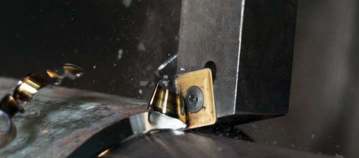

Obróbka zgrubna (kształtowanie bryły elementu)

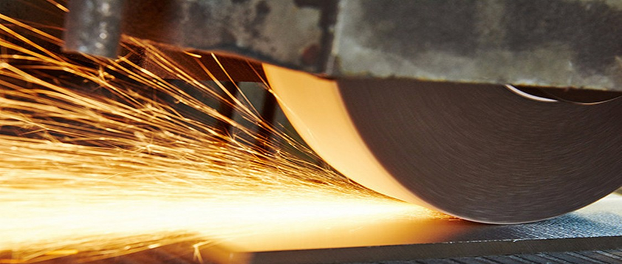

Obróbka pośrednia (zmniejszanie błędów wymiarowych)

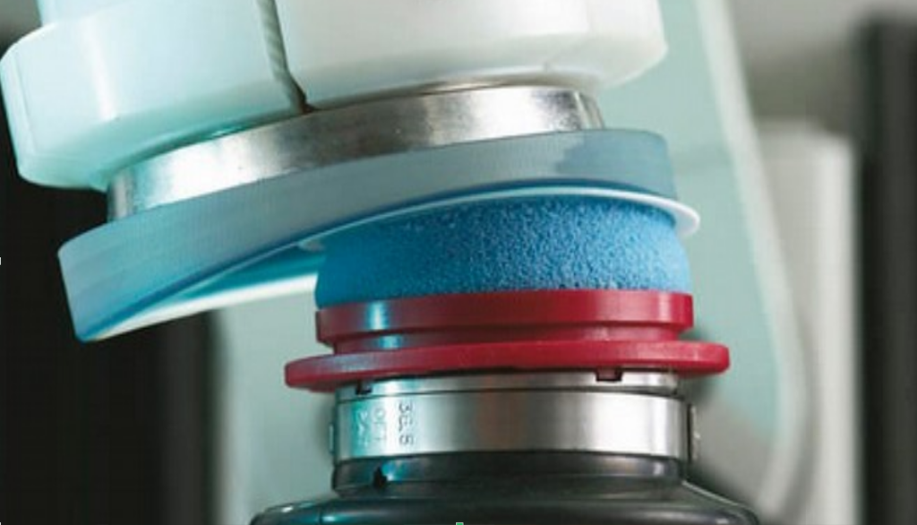

Obróbka wykończeniowa - finalna

Sandvik Coromant, Fawor, Schneider Optics

## WPROWADZENIE

### OBRÓBKA DOKŁADNOŚCIOWO-GŁADKOŚCIOWA

Szereg procesów stosowanych przy obróbce wykończeniowej

- makrogeometria elementu,
- mikrogeometria powierzchni,
- formowanie warstw wierzchnich i powłok.

[figure not shown]

## WPROWADZENIE

### WARSTWA WIERZCHNIA ELEMENTÓW

„Warstwa wierzchnia to ta część materiału przylegająca do powierzchni wraz z powierzchnią, której własności fizyczne różnią się od reszty materiału nazywanego dalej rdzeniem”

Technologiczna warstwa wierzchnia PN-EN 15305, PN-EN ISO 2639, PN-ISO 14104, PN-EN ISO 21920, ISO 7599 (*stara norma PN-87/M-04250*)

**Powierzchnia elementu ≠ Warstwa wierzchnia**

**Powierzchnia elementu ≠ Powłoka elementu**

**Powierzchnia elementu = granica faz/ośrodków**

[figure not shown]

Burakowski T., Wierzchoń T.: Inżynieria powierzchni metali – podstawy, urządzenia, technologie. WNT, Warszawa 1995.

## WPROWADZENIE

### WARSTWA WIERZCHNIA ELEMENTÓW - CHARAKTERYSTYKA

Określony cel (jeden lub wiele, często niepełne).

- antykorozja
- utwardzanie
- umacnianie
- dekoracja
- termiczne
- dielektryczne
- …

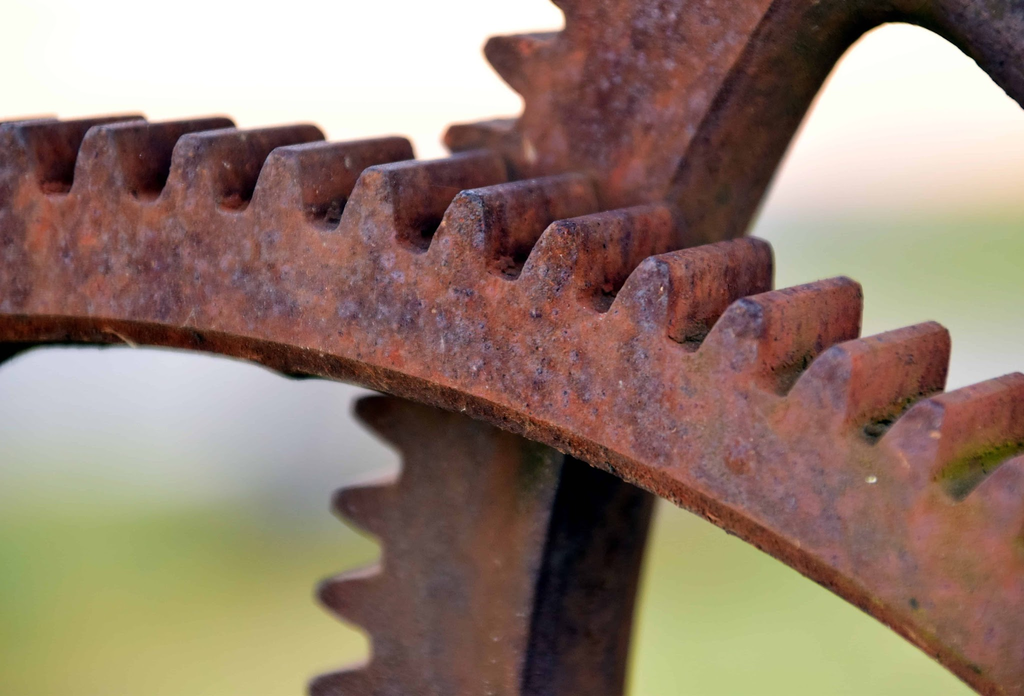

[figure not shown]

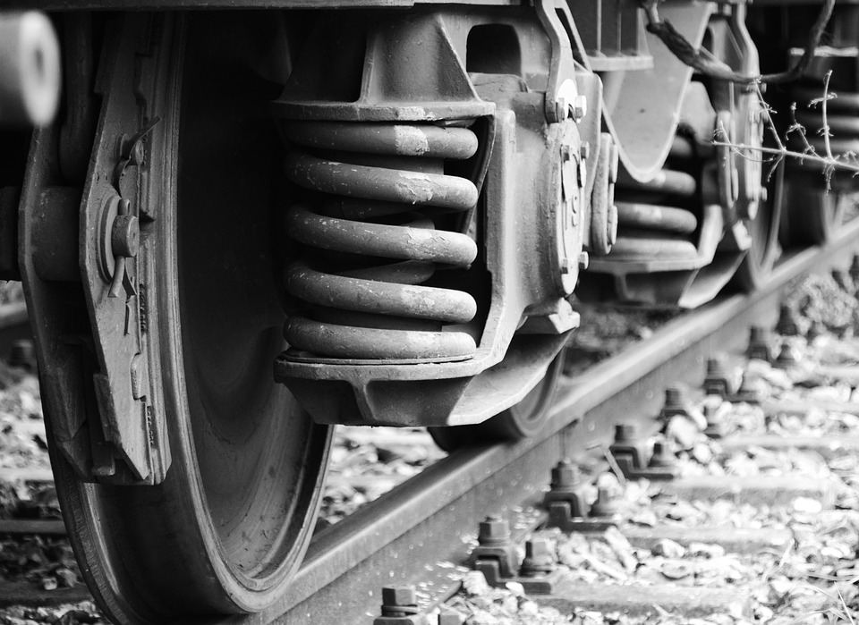

[figure not shown]

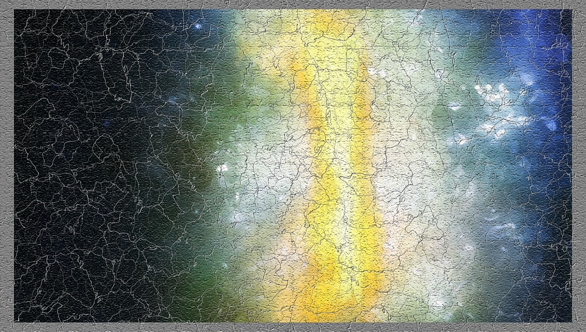

## WPROWADZENIE

### WARSTWA WIERZCHNIA ELEMENTÓW - CHARAKTERYSTYKA

**Właściwości:**

- stereometryczne (chropowatość, falistość, nośność, kierunkowość śladów),
- fizykochemiczne (mechaniczne, chemiczne, cieplne, fizyczne, elektryczne, magnetyczne),
- strukturalne (grubość, struktura, mikrotwardość, naprężenia, wady).

**Stan warstwy wierzchniej:**

chropowatość, falistość, nośność, energia powierzchniowa, napięcie powierzchniowe, emisyjność, odbijalność, pochłanialność (adsorpcja fizyczna), budowa, grubość, twardość, kruchość, naprężenia własne, skład chemiczny, absorpcja chemiczna, adsorpcja chemiczna (chemisorpcja), adsorpcja fizyczna (fizykosorpcja), rozpuszczalność, dyfuzja, kataliza, przewodność, rozszerzalność, adhezja, rezystywność, koercja, przenikalność.

## WPROWADZENIE

### WARSTWA WIERZCHNIA ELEMENTÓW - OTRZYMYWANIE

- niszczenie lub modyfikacja wcześniejszej warstwy
- nowa powierzchnia fizyczna
- zmiana właściwości istniejącej powierzchni

[figure not shown]

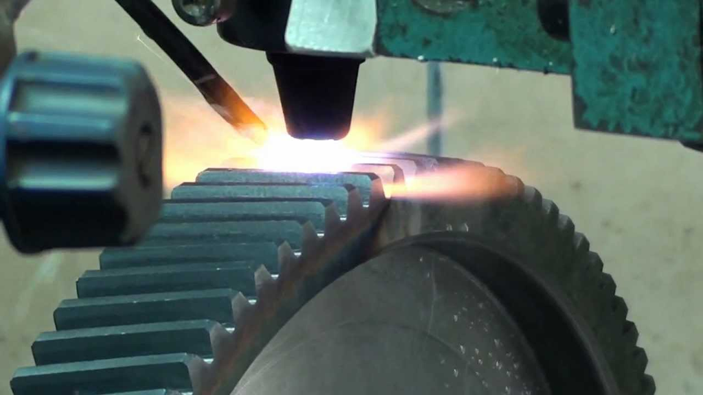

## WPROWADZENIE

### WARSTWA WIERZCHNIA ELEMENTÓW - OTRZYMYWANIE

Norma PN-ISO 1302 „Rysunek techniczny - Oznaczanie struktury geometrycznej powierzchni” zawiera sposoby określania chropowatości na rysunkach technicznych i metody jej uzyskania.

- struktura powierzchni uzyskana w dowolnym procesie obróbki
- struktura powierzchni uzyskana wyłącznie przez zdjęcie materiału – obróbka skrawaniem
- struktura powierzchni uzyskana za pomocą innego procesu niż zdjęcie materiału
- chropowatość powierzchni zawiera się między wartościami a i b
- struktura powierzchni uzyskana ściśle określonym rodzajem obróbki.

Te same zasady dotyczą obróbki cieplnej i cieplno-chemicznej.

[figure not shown]

## HARTOWANIE POWIERZCHNIOWE

Szybkie nagrzanie warstwy wierzchniej do temperatury austenityzacji (zwykle ok. 100°C powyżej temperatury przemiany A<sub>C3</sub>), a następnie szybkie chłodzenie przez natrysk wody lub emulsji hartowniczej, w celu uzyskania struktury martenzytycznej na powierzchni i struktury niezahartowanej pod powierzchnią.

**Rodzaje:** płomieniowe, indukcyjne, kąpielowe, laserowe, oporowe, elektrolityczne, …

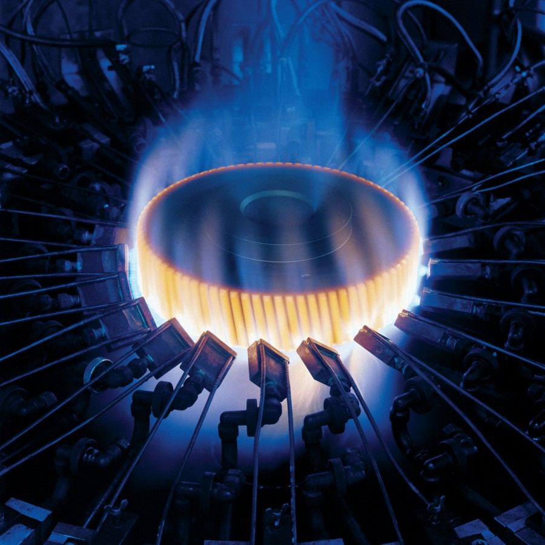

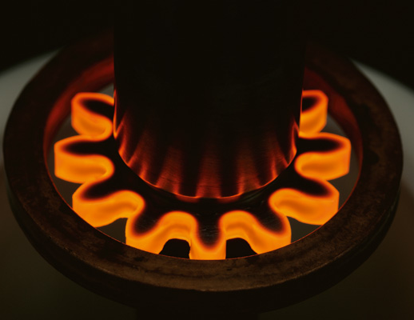

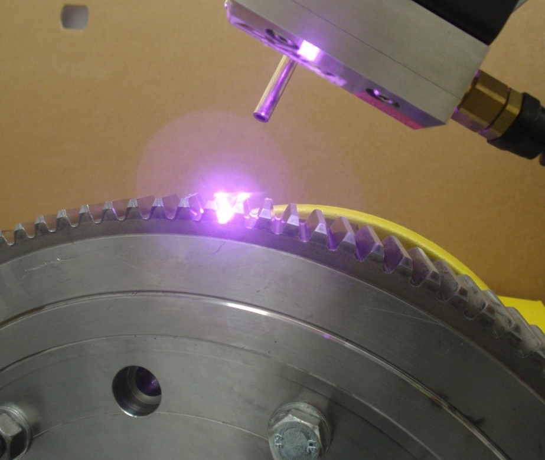

Gerster, EFD Induction, NTC-TTP

## HARTOWANIE POWIERZCHNIOWE

### Hartowanie płomieniowe

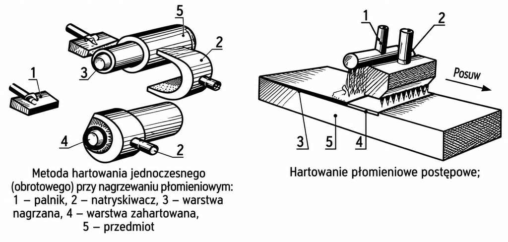

## HARTOWANIE POWIERZCHNIOWE

### Hartowanie płomieniowe

[interactive chart not shown]

Andrzej Maciąg https://www.youtube.com/watch?v=6CKoUsEdy2I

## HARTOWANIE POWIERZCHNIOWE

### Hartowanie indukcyjne

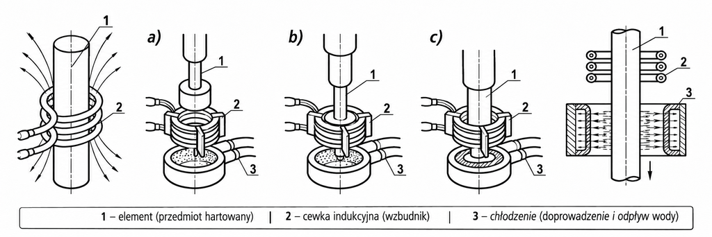

## HARTOWANIE POWIERZCHNIOWE

### Hartowanie indukcyjne

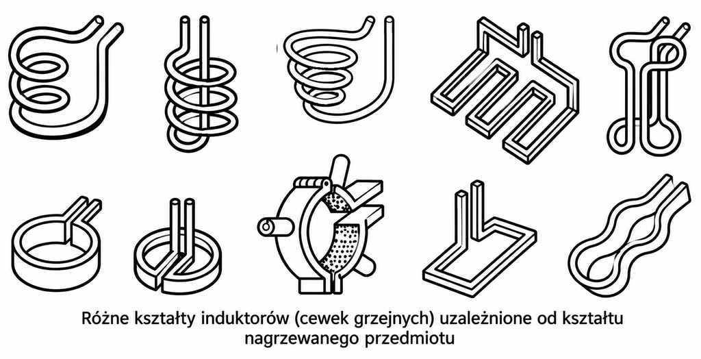

## HARTOWANIE POWIERZCHNIOWE

### Hartowanie indukcyjne

[interactive chart not shown]

Henk https://www.youtube.com/watch?v=Dp604A3CmkA

## HARTOWANIE POWIERZCHNIOWE

### Hartowanie indukcyjne

[interactive chart not shown]

Adam Ambrozy https://www.youtube.com/watch?v=jFpwReMHHRE